# Patel_MSDS458_Assignment2_E8_DNN3_with_regularization

[figure not shown]

## MSDS458 Research Assignment Experiment8 DNN3 With Regularization

EXPERIMENT 8: In this notebook, we will build a DNN model with total 3 hidden layers in which 2 hidden layers have 64 nodes and 1 hidden layer have 32 nodes with regularization on the CIFAR-10 data.

- early stopping: stop training as soon as the validation error reaches minimum
- dropout: randomly selecting 30% of the nodes and removing them from their incoming and outgoing connections.
- L2 regularization: Ridge regression is the sum of the squares of all the feature weights. It is used to prevent overfitting by penalizing complex models. batch-size

**The CIFAR-10 dataset**  
https://www.cs.toronto.edu/~kriz/cifar.html

## Importing packages needed

```python
import datetime
import time
import numpy as np
import pandas as pd
from packaging import version
from collections import Counter

from sklearn.metrics import confusion_matrix, classification_report
from sklearn.metrics import accuracy_score
from sklearn.metrics import mean_squared_error as MSE
from sklearn.model_selection import train_test_split
from sklearn.manifold import TSNE

import matplotlib.pyplot as plt
import matplotlib as mpl
from mpl_toolkits.mplot3d import Axes3D
import seaborn as sns

import tensorflow as tf
from tensorflow import keras
from tensorflow.keras import models, layers
from tensorflow.keras.models import Sequential
from tensorflow.keras.layers import Conv2D, MaxPool2D, BatchNormalization, Dropout, Flatten, Input, Dense
from tensorflow.keras.callbacks import ModelCheckpoint, EarlyStopping
from tensorflow.keras.preprocessing import image
from tensorflow.keras.utils import to_categorical

# To get consistint results each time we rerun the code.
keras.backend.clear_session()
np.random.seed(42)
tf.random.set_seed(42)
```

```python
%matplotlib inline
np.set_printoptions(precision=3, suppress=True)
```

### Verifying TensorFlow Version and Keras Version

```python
print("This notebook requires TensorFlow 2.0 or above")
print("TensorFlow version: ", tf.__version__)
assert version.parse(tf.__version__).release[0] >=2
```

```
This notebook requires TensorFlow 2.0 or above
TensorFlow version:  2.9.2
```

```python
print("Keras version: ", keras.__version__)
```

```
Keras version:  2.9.0
```

### Mount Google Drive to Colab Environment

```python
from google.colab import drive
drive.mount('/content/gdrive')
```

### Functions for Research Assignment

```python
def print_validation_report(y_test, predictions):
    print("Classification Report")
    print(classification_report(y_test, predictions))
    print('Accuracy Score: {}'.format(accuracy_score(y_test, predictions)))
    print('Root Mean Square Error: {}'.format(np.sqrt(MSE(y_test, predictions))))
```

```python
def plot_confusion_matrix(y_true, y_pred):
    mtx = confusion_matrix(y_true, y_pred)
    fig, ax = plt.subplots(figsize=(8,8))
    sns.heatmap(mtx, annot=True, fmt='d', linewidths=.75,  cbar=False, ax=ax,cmap='Blues',linecolor='white')
    #  square=True,
    plt.ylabel('true label')
    plt.xlabel('predicted label')
```

### Model Performance and Metrics Functions

## Loading CIFAR-10 Dataset

```python
(x_train, y_train), (x_test, y_test) = keras.datasets.cifar10.load_data()
```

```
Downloading data from https://www.cs.toronto.edu/~kriz/cifar-10-python.tar.gz
```

```python
print('x_train:\t{}'.format(x_train.shape))
print('y_train:\t{}'.format(y_train.shape))
print('x_test:\t{}'.format(x_test.shape))
print('y_test:\t{}'.format(y_test.shape))
```

```
x_train:	(50000, 32, 32, 3)
y_train:	(50000, 1)
x_test:	(10000, 32, 32, 3)
y_test:	(10000, 1)
```

## Preprocess Data For Model Development

| Label | Class_ |
| --- | --- |
| 0 | airplane |
| 1 | automobile |
| 2 | bird |
| 3 | cat |
| 4 | deer |
| 5 | dog |
| 6 | frog |
| 7 | horse |
| 8 | ship |
| 9 | truck |

```python
class_names = ['airplane'
,'automobile'
,'bird'
,'cat'
,'deer'
,'dog'
,'frog'
,'horse'
,'ship'
,'truck']
```

### Rescaling elements between 0 and 1 for {Train, Validation, Test}

The images are 32x32x3 NumPy arrays, with pixel value between 0 and 255.

```python
x_train_reshaped = x_train.reshape((50000, 32 * 32 * 3))
x_train_norm = x_train_reshaped.astype('float32') /255

x_test_reshaped = x_test.reshape((10000, 32 * 32 * 3))
x_test_norm = x_test_reshaped.astype('float32') / 255
```

### Model Functions and Performance Metrics for Research Assignment

```python
def print_validation_report(y_test, predictions):
    print("Classification Report")
    print(classification_report(y_test, predictions))
    print('Accuracy Score: {}'.format(accuracy_score(y_test, predictions)))
    print('Root Mean Square Error: {}'.format(np.sqrt(MSE(y_test, predictions))))
```

```python
def plot_confusion_matrix(y_true, y_pred):
    mtx = confusion_matrix(y_true, y_pred)
    fig, ax = plt.subplots(figsize=(8,8))
    sns.heatmap(mtx, annot=True, fmt='d', linewidths=.75,  cbar=False, ax=ax,cmap='Blues',linecolor='white')
    #  square=True,
    plt.ylabel('true label')
    plt.xlabel('predicted label')
```

```python
def plot_history(history):
  losses = history.history['loss']
  accs = history.history['accuracy']
  val_losses = history.history['val_loss']
  val_accs = history.history['val_accuracy']
  epochs = len(losses)

  plt.figure(figsize=(16, 4))
  for i, metrics in enumerate(zip([losses, accs], [val_losses, val_accs], ['Loss', 'Accuracy'])):
    plt.subplot(1, 2, i + 1)
    plt.plot(range(epochs), metrics[0], label='Training {}'.format(metrics[2]))
    plt.plot(range(epochs), metrics[1], label='Validation {}'.format(metrics[2]))
    plt.legend()
  plt.show()
```

### Building DNN Model with 3 hidden layers With L2 Regularization and 30% Dropout rate

```python
model = models.Sequential()
model.add(layers.Dense(64, activation='relu', input_shape=[3072]))
model.add(layers.Dropout(0.3))
model.add(layers.Dense(64, activation='relu', kernel_regularizer=tf.keras.regularizers.L2(0.001)))
model.add(layers.Dropout(0.3))
model.add(layers.Dense(32, activation='relu', kernel_regularizer=tf.keras.regularizers.L2(0.001)))
model.add(layers.Dropout(0.3))
model.add(layers.Dense(10, activation='softmax'))
```

```python
model.summary()
```

```
Model: "sequential"
_________________________________________________________________
 Layer (type)                Output Shape              Param #
=================================================================
 dense (Dense)               (None, 64)                196672

 dropout (Dropout)           (None, 64)                0

 dense_1 (Dense)             (None, 64)                4160

 dropout_1 (Dropout)         (None, 64)                0

 dense_2 (Dense)             (None, 32)                2080

 dropout_2 (Dropout)         (None, 32)                0

 dense_3 (Dense)             (None, 10)                330

=================================================================
Total params: 203,242
Trainable params: 203,242
Non-trainable params: 0
_________________________________________________________________
```

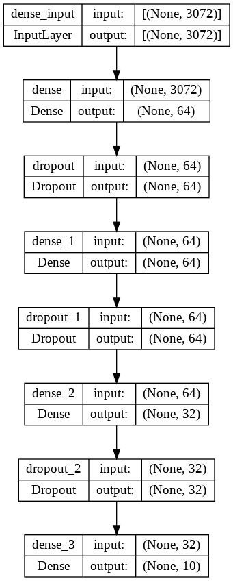

```python
keras.utils.plot_model(model, "CIFAR10.png", show_shapes=True)
```

### Compiling and training the model

```python
# Compile and train
model_filename = "Model2_Experiment8_DNN3_WithRegularization.h5"

model.compile(optimizer='adam',
              loss=tf.keras.losses.SparseCategoricalCrossentropy(from_logits=False),
              metrics=['accuracy'])

start = datetime.datetime.now()
history = model.fit(x_train_norm
                   ,y_train
                   ,batch_size = 100
                   ,epochs = 20
                   ,validation_split=0.10
                   ,callbacks=[
                      tf.keras.callbacks.ModelCheckpoint(model_filename,
                                                         save_best_only=True,save_weights_only=False)
                     ,tf.keras.callbacks.EarlyStopping(monitor='val_accuracy', patience=3),
                    ])
end = datetime.datetime.now()
time_diff = end - start
print(f'Finished model training in {time_diff}')
```

```
Finished model training in 0:00:16.538512
```

### Evaluating the performance accuracy on the Train, Validation, and Test set.

```python
hist_dict = history.history
hist_dict.keys()
print('Evaluating model performance accuracy with Training and Validation dataset:')
print(f'''acc: {hist_dict['accuracy'][-1]:.4}, val acc: {hist_dict['val_accuracy'][-1]:.4},
loss: {hist_dict['loss'][-1]:.4}, val loss: {hist_dict['val_loss'][-1]:.4}''')

loss, accuracy = model.evaluate(x_test_norm, y_test)
print('Evaluating model performance accuracy with Test dataset: ', accuracy * 100)
```

```
Evaluating model performance accuracy with Training and Validation dataset:
acc: 0.1972, val acc: 0.219,
loss: 2.084, val loss: 2.051
Evaluating model performance accuracy with Test dataset:  21.969999372959137
```

## Predictions

```python
preds = model.predict(x_test_norm)
print('shape of preds: ', preds.shape)
```

```
shape of preds:  (10000, 10)
```

## Plotting Performance Metrics

We use Matplotlib to create 2 plots--displaying the training and validation loss (resp. accuracy) for each (training) epoch side by side.

```python
history_dict = history.history
history_dict.keys()
```

```
dict_keys(['loss', 'accuracy', 'val_loss', 'val_accuracy'])
```

```python
history_df=pd.DataFrame(history_dict)
history_df.tail().round(3)
```

|  | loss | accuracy | val_loss | val_accuracy |
| --- | --- | --- | --- | --- |
| 3 | 2.109 | 0.185 | 2.044 | 0.208 |
| 4 | 2.103 | 0.191 | 2.040 | 0.231 |
| 5 | 2.090 | 0.194 | 2.035 | 0.230 |
| 6 | 2.090 | 0.193 | 2.039 | 0.220 |
| 7 | 2.084 | 0.197 | 2.051 | 0.219 |

```python
losses = history.history['loss']
accs = history.history['accuracy']
val_losses = history.history['val_loss']
val_accs = history.history['val_accuracy']
epochs = len(losses)
```

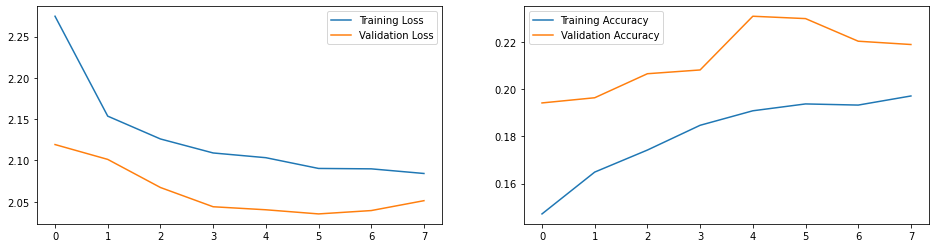

```python
plt.figure(figsize=(16, 4))
for i, metrics in enumerate(zip([losses, accs], [val_losses, val_accs], ['Loss', 'Accuracy'])):
    plt.subplot(1, 2, i + 1)
    plt.plot(range(epochs), metrics[0], label='Training {}'.format(metrics[2]))
    plt.plot(range(epochs), metrics[1], label='Validation {}'.format(metrics[2]))
    plt.legend()
plt.show()
```

## Confusion matrices

Using both `sklearn.metrics`. Then we visualize the confusion matrix and see what that tells us.

```python
pred1= model.predict(x_test_norm)
pred1=np.argmax(pred1, axis=1)
```

```python
print_validation_report(y_test, pred1)
```

```
Classification Report
              precision    recall  f1-score   support

           0       0.40      0.40      0.40      1000
           1       0.32      0.56      0.41      1000
           2       0.11      0.02      0.04      1000
           3       0.10      0.04      0.06      1000
           4       0.00      0.00      0.00      1000
           5       0.14      0.13      0.14      1000
           6       0.18      0.87      0.30      1000
           7       0.08      0.03      0.05      1000
           8       0.45      0.11      0.18      1000
           9       0.21      0.03      0.05      1000

    accuracy                           0.22     10000
   macro avg       0.20      0.22      0.16     10000
weighted avg       0.20      0.22      0.16     10000

Accuracy Score: 0.2197
Root Mean Square Error: 3.799986842082483
```

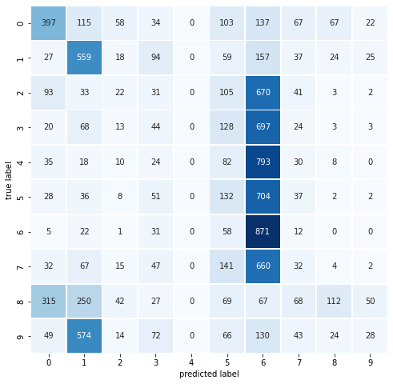

```python
plot_confusion_matrix(y_test,pred1)
```

### Predictions

```python
cm = sns.light_palette((260, 75, 60), input="husl", as_cmap=True)
```

```python
df = pd.DataFrame(preds[0:20], columns = ['airplane', 'automobile', 'bird', 'cat', 'deer', 'dog', 'frog', 'horse', 'ship', 'truck'])
df.style.format("{:.2%}").background_gradient(cmap=cm)
```

|  | airplane | automobile | bird | cat | deer | dog | frog | horse | ship | truck |
| --- | --- | --- | --- | --- | --- | --- | --- | --- | --- | --- |
| 0 | 5.30% | 6.06% | 12.83% | 12.82% | 13.23% | 13.75% | 14.17% | 13.22% | 3.77% | 4.84% |
| 1 | 7.49% | 36.90% | 1.29% | 2.12% | 0.89% | 0.99% | 0.51% | 1.82% | 15.21% | 32.78% |
| 2 | 18.06% | 18.05% | 6.47% | 4.30% | 3.64% | 3.17% | 1.22% | 4.71% | 21.02% | 19.37% |
| 3 | 18.37% | 11.52% | 11.35% | 6.68% | 6.58% | 6.15% | 2.45% | 7.54% | 16.61% | 12.74% |
| 4 | 4.45% | 5.01% | 13.25% | 12.45% | 14.73% | 13.79% | 16.30% | 13.21% | 3.02% | 3.79% |
| 5 | 4.45% | 5.01% | 13.25% | 12.45% | 14.73% | 13.79% | 16.30% | 13.21% | 3.02% | 3.79% |
| 6 | 4.45% | 5.01% | 13.25% | 12.45% | 14.73% | 13.79% | 16.30% | 13.21% | 3.02% | 3.79% |
| 7 | 4.45% | 5.01% | 13.25% | 12.45% | 14.73% | 13.79% | 16.30% | 13.21% | 3.02% | 3.79% |
| 8 | 4.45% | 5.01% | 13.25% | 12.45% | 14.73% | 13.79% | 16.30% | 13.21% | 3.02% | 3.79% |
| 9 | 11.67% | 28.88% | 2.80% | 2.99% | 1.76% | 1.69% | 0.76% | 2.93% | 18.66% | 27.85% |
| 10 | 17.81% | 11.86% | 11.20% | 6.82% | 6.62% | 6.24% | 2.64% | 7.66% | 16.21% | 12.95% |
| 11 | 8.01% | 34.83% | 1.87% | 3.20% | 1.42% | 1.66% | 1.03% | 2.69% | 14.66% | 30.64% |
| 12 | 4.45% | 5.01% | 13.25% | 12.45% | 14.73% | 13.79% | 16.30% | 13.21% | 3.02% | 3.79% |
| 13 | 7.34% | 11.25% | 10.02% | 12.56% | 9.43% | 11.45% | 9.88% | 12.04% | 6.47% | 9.56% |
| 14 | 8.95% | 13.93% | 9.17% | 11.29% | 7.93% | 9.74% | 7.22% | 10.81% | 8.55% | 12.41% |
| 15 | 6.71% | 7.55% | 12.44% | 12.83% | 11.57% | 13.24% | 11.20% | 12.98% | 5.07% | 6.41% |
| 16 | 5.47% | 6.26% | 12.77% | 12.85% | 12.98% | 13.72% | 13.78% | 13.20% | 3.92% | 5.04% |
| 17 | 4.94% | 5.62% | 12.96% | 12.69% | 13.81% | 13.78% | 15.10% | 13.23% | 3.45% | 4.41% |
| 18 | 15.34% | 24.65% | 3.07% | 2.22% | 1.60% | 1.27% | 0.44% | 2.36% | 23.21% | 25.83% |
| 19 | 4.45% | 5.01% | 13.25% | 12.45% | 14.73% | 13.79% | 16.30% | 13.21% | 3.02% | 3.79% |

```python
preds = model.predict(x_test_norm)
print('shape of preds: ', preds.shape)
```

```
shape of preds:  (10000, 10)
```

### Make Predictions

Look at the first 25 - Plot validation set images along with their predicted and actual labels to understand how the trained model actually performed

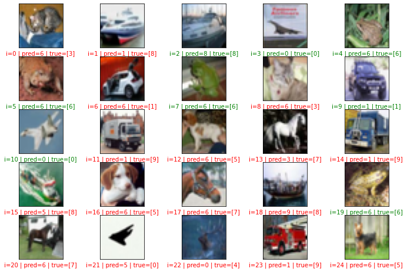

```python
plt.figure(figsize = (12, 8))

start_index = 0

for i in range(25):
    plt.subplot(5, 5, i + 1)
    plt.grid(False)
    plt.xticks([])
    plt.yticks([])
    pred = np.argmax(preds[start_index + i])
    actual = y_test[start_index + i]
    col = 'g'
    if pred != actual:
        col = 'r'
    plt.xlabel('i={} | pred={} | true={}'.format(start_index + i, pred, actual), color = col)
    plt.imshow(x_test[start_index + i], cmap='binary')
plt.show()
```

```python
# Extracts the outputs of all layers:
layer_outputs = [layer.output for layer in model.layers]

# Creates a model that will return these outputs, given the model input:
activation_model = models.Model(inputs=model.input, outputs=layer_outputs)

# Get activation values for the last dense layer
activations = activation_model.predict(x_train_norm[:3250])
dense_layer_activations = activations[-3]
output_layer_activations = activations[-1]
```

## sklearn.manifold.TSNE Experiment 8 DNN 3 Hidden Layers With Regularization

https://scikit-learn.org/stable/modules/generated/sklearn.manifold.TSNE.html

```python
# Reduce the dimension using T-SNE to visualize i n a scatterplot
tsne = TSNE(n_components=2, verbose=1, perplexity=40, n_iter=300)
tsne_results = tsne.fit_transform(dense_layer_activations)

# Scaling
tsne_results = (tsne_results - tsne_results.min()) / (tsne_results.max() - tsne_results.min())
```

```
[t-SNE] Computing 121 nearest neighbors...
[t-SNE] Indexed 3250 samples in 0.000s...
```

```
[t-SNE] Computed neighbors for 3250 samples in 0.264s...
[t-SNE] Computed conditional probabilities for sample 1000 / 3250
[t-SNE] Computed conditional probabilities for sample 2000 / 3250
[t-SNE] Computed conditional probabilities for sample 3000 / 3250
[t-SNE] Computed conditional probabilities for sample 3250 / 3250
[t-SNE] Mean sigma: 0.000000
[t-SNE] KL divergence after 250 iterations with early exaggeration: 59.208611
[t-SNE] KL divergence after 300 iterations: 0.712209
```

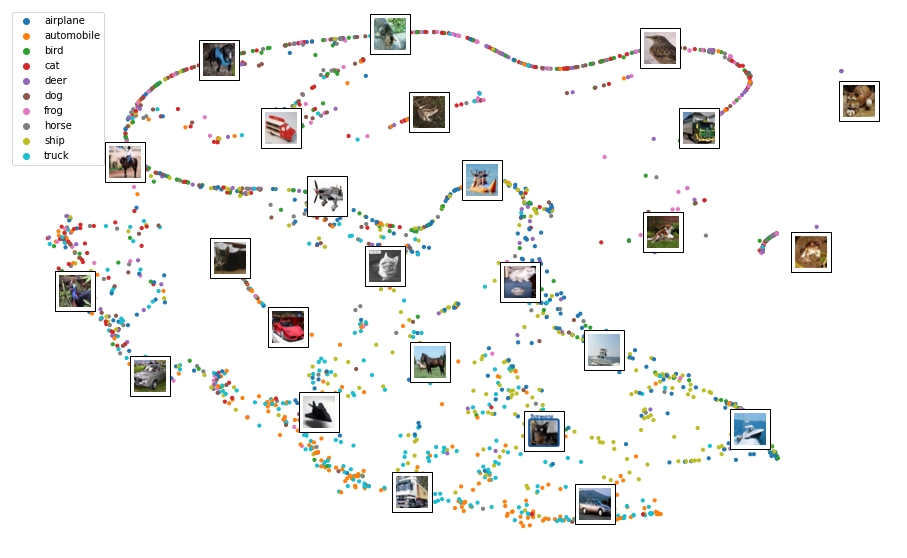

```python
cmap = plt.cm.tab10
plt.figure(figsize=(16,10))
scatter = plt.scatter(tsne_results[:,0],tsne_results[:,1], c=y_train[:3250], s=10, cmap=cmap)
plt.legend(handles=scatter.legend_elements()[0], labels=class_names)

image_positions = np.array([[1., 1.]])
for index, position in enumerate(tsne_results):
    dist = np.sum((position - image_positions) ** 2, axis=1)
    if np.min(dist) > 0.02: # if far enough from other images
        image_positions = np.r_[image_positions, [position]]
        imagebox = mpl.offsetbox.AnnotationBbox(
            mpl.offsetbox.OffsetImage(x_train[index], cmap="binary"),
            position, bboxprops={"lw": 1})
        plt.gca().add_artist(imagebox)
plt.axis("off")
plt.show()
```